# BIOF 440: Data visualization using Python

## Homework 6

```python
import numpy as np
import pandas as pd
import statsmodels.api as sm
import statsmodels.formula.api as smf

import matplotlib.pyplot as plt
import matplotlib as mpl

plt.style.use('seaborn-notebook')
mpl.rc('font', **{'family': 'serif', 'serif': 'Palatino'})
```

## Question 1 (10 points)

We’ll use the data set beaches to fit a linear regression of $\log_{10}$(enterococci) on other variables.

Create a plot of the coefficients and 95% confidence intervals of this model, including a reference line at 0. State which variables and levels are statistically significant. Order the months in chronological order, with January being the reference month. Make the plot publication quality, in that the graph shouldn’t have raw variable names, and should have appropriate titles and axes labels and legends (in English).

```python
dat = pd.read_csv('data/sydneybeaches3.csv')
dat.head()
```

|  | date | year | month | day | season | rainfall | temperature | enterococci | day_num | month_num | month_name | season_name |
| --- | --- | --- | --- | --- | --- | --- | --- | --- | --- | --- | --- | --- |
| 0 | 2013-01-02 | 2013 | 1 | 2 | 1 | 0.0 | 23.4 | 6.7 | 2 | 1 | January | Summer |
| 1 | 2013-01-06 | 2013 | 1 | 6 | 1 | 0.0 | 30.3 | 2.0 | 6 | 1 | January | Summer |
| 2 | 2013-01-12 | 2013 | 1 | 12 | 1 | 0.0 | 31.4 | 69.1 | 12 | 1 | January | Summer |
| 3 | 2013-01-18 | 2013 | 1 | 18 | 1 | 0.0 | 46.4 | 9.0 | 18 | 1 | January | Summer |
| 4 | 2013-01-24 | 2013 | 1 | 24 | 1 | 0.0 | 27.5 | 33.9 | 24 | 1 | January | Summer |

```python
tmp=dat[['month','month_name']].drop_duplicates()
dat['month_name'] = pd.Categorical(dat['month_name'], categories=tmp['month_name']) # This assures the months are in the right order in the table and graph
```

```python
mod = smf.ols(formula = "np.log10(enterococci) ~ rainfall + temperature + month_name ", data=dat)
res = mod.fit()
```

```python
coefs = res.summary2().tables[1].reset_index().rename(columns = {'index':'variables'})

coefs
```

|  | variables | Coef. | Std.Err. | t | P>\|t\| | [0.025 | 0.975] |
| --- | --- | --- | --- | --- | --- | --- | --- |
| 0 | Intercept | 1.514832 | 0.240989 | 6.285891 | 1.066534e-09 | 1.040709 | 1.988956 |
| 1 | month_name[T.February] | 0.072158 | 0.136057 | 0.530354 | 5.962346e-01 | -0.195521 | 0.339838 |
| 2 | month_name[T.March] | 0.045136 | 0.136024 | 0.331824 | 7.402392e-01 | -0.222478 | 0.312750 |
| 3 | month_name[T.April] | 0.016957 | 0.143073 | 0.118520 | 9.057298e-01 | -0.264525 | 0.298440 |
| 4 | month_name[T.May] | -0.276641 | 0.142712 | -1.938460 | 5.344634e-02 | -0.557412 | 0.004131 |
| 5 | month_name[T.June] | -0.078248 | 0.150231 | -0.520851 | 6.028311e-01 | -0.373814 | 0.217318 |
| 6 | month_name[T.July] | -0.546687 | 0.155701 | -3.511143 | 5.102697e-04 | -0.853013 | -0.240361 |
| 7 | month_name[T.August] | -0.722328 | 0.150745 | -4.791718 | 2.534984e-06 | -1.018905 | -0.425751 |
| 8 | month_name[T.September] | -0.614394 | 0.137367 | -4.472649 | 1.074572e-05 | -0.884650 | -0.344138 |
| 9 | month_name[T.October] | -0.316655 | 0.143912 | -2.200330 | 2.849778e-02 | -0.599789 | -0.033521 |
| 10 | month_name[T.November] | -0.194027 | 0.146056 | -1.328446 | 1.849774e-01 | -0.481378 | 0.093324 |
| 11 | month_name[T.December] | 0.065870 | 0.143116 | 0.460255 | 6.456459e-01 | -0.215697 | 0.347436 |
| 12 | rainfall | 0.025149 | 0.002845 | 8.839601 | 6.542928e-17 | 0.019552 | 0.030747 |
| 13 | temperature | -0.015307 | 0.007482 | -2.045793 | 4.159399e-02 | -0.030027 | -0.000587 |

```python
coefs['variables'] = coefs['variables'].str.replace('month_name\[T.','').str.replace('\]', '') # fixes the format of the month coefficients
coefs.query('variables != "Intercept"', inplace=True) # Takes out the row with the intercept
coefs
```

|  | variables | Coef. | Std.Err. | t | P>\|t\| | [0.025 | 0.975] |
| --- | --- | --- | --- | --- | --- | --- | --- |
| 1 | February | 0.072158 | 0.136057 | 0.530354 | 5.962346e-01 | -0.195521 | 0.339838 |
| 2 | March | 0.045136 | 0.136024 | 0.331824 | 7.402392e-01 | -0.222478 | 0.312750 |
| 3 | April | 0.016957 | 0.143073 | 0.118520 | 9.057298e-01 | -0.264525 | 0.298440 |
| 4 | May | -0.276641 | 0.142712 | -1.938460 | 5.344634e-02 | -0.557412 | 0.004131 |
| 5 | June | -0.078248 | 0.150231 | -0.520851 | 6.028311e-01 | -0.373814 | 0.217318 |
| 6 | July | -0.546687 | 0.155701 | -3.511143 | 5.102697e-04 | -0.853013 | -0.240361 |
| 7 | August | -0.722328 | 0.150745 | -4.791718 | 2.534984e-06 | -1.018905 | -0.425751 |
| 8 | September | -0.614394 | 0.137367 | -4.472649 | 1.074572e-05 | -0.884650 | -0.344138 |
| 9 | October | -0.316655 | 0.143912 | -2.200330 | 2.849778e-02 | -0.599789 | -0.033521 |
| 10 | November | -0.194027 | 0.146056 | -1.328446 | 1.849774e-01 | -0.481378 | 0.093324 |
| 11 | December | 0.065870 | 0.143116 | 0.460255 | 6.456459e-01 | -0.215697 | 0.347436 |
| 12 | rainfall | 0.025149 | 0.002845 | 8.839601 | 6.542928e-17 | 0.019552 | 0.030747 |
| 13 | temperature | -0.015307 | 0.007482 | -2.045793 | 4.159399e-02 | -0.030027 | -0.000587 |

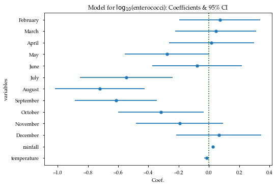

```python
import seaborn as sns

fig, ax = plt.subplots()

sns.scatterplot(data=coefs, x = "Coef.", y = "variables", ax = ax)
ax.hlines(
    y = coefs['variables'],
    xmin = coefs['[0.025'],
    xmax = coefs['0.975]']
)
ax.axvline(0, linestyle=':', color='green');
ax.set_title('Model for $\log_{10}$(enterococci): Coefficients & 95% CI');
```

## Extra credit

Color the plot according to which variables and levels are significant.

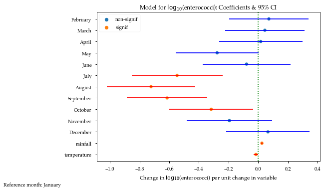

```python
coefs['indic'] = pd.Categorical(np.where(coefs['P>|t|'] < 0.05, 'signif', 'non-signif'), categories=['non-signif','signif'])

fig, ax = plt.subplots()

sns.scatterplot(data=coefs, x = "Coef.", y = "variables", hue = "indic", ax = ax)
ax.hlines(
    y = coefs['variables'],
    xmin = coefs['[0.025'],
    xmax = coefs['0.975]'],
    colors = np.where(coefs['indic']=='signif', 'red','blue'),
)
ax.axvline(0, linestyle=':', color='green'); # vertical line
ax.set_ylabel("");
ax.set_xlabel('Change in $\log_{10}$(enterococci) per unit change in variable');
ax.set_title('Model for $\log_{10}$(enterococci): Coefficients & 95% CI');
ax.legend(title = "", loc='upper left');
fig.text(0, 0.0001, 'Reference month: January', ha='right'); # location with respect to figure, not axes
```

## Question 2

```python
accidents = pd.read_csv('data/accidents2019.csv')
accidents['Month'] = pd.Categorical(accidents['Month'], # This sets the right order of months
    categories=['January','February','March','April','May','June','July',
        'August','September','October','November', 'December'])
accidents['Drunk'] = accidents.Drunk/accidents.N * 100
accidents['Urban'] = accidents.Urban/accidents.N * 100
accidents.head()
```

|  | Unnamed: 0 | Month | Hour | Drunk | Urban | N |
| --- | --- | --- | --- | --- | --- | --- |
| 0 | 0 | April | 0.0 | 46.666667 | 63.809524 | 105 |
| 1 | 1 | April | 1.0 | 52.427184 | 65.048544 | 103 |
| 2 | 2 | April | 2.0 | 56.603774 | 60.377358 | 106 |
| 3 | 3 | April | 3.0 | 41.666667 | 65.277778 | 72 |
| 4 | 4 | April | 4.0 | 27.659574 | 68.085106 | 47 |

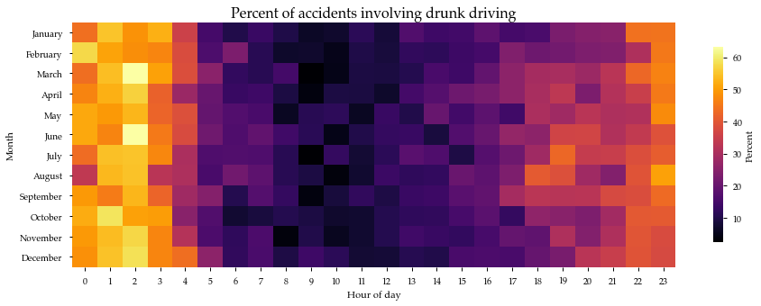

```python
plot_dat = accidents[['Month','Hour','Drunk']].pivot(index = 'Month',columns = 'Hour')
fig, ax = plt.subplots(figsize = (15, 5))
sns.heatmap(plot_dat, cmap='inferno', ax=ax,
    cbar_kws={'shrink':0.8, 'label': 'Percent'})
ax.set_xlabel('Hour of day');
ax.set_xticklabels(list(range(24)), rotation=0);
ax.set_title('Percent of accidents involving drunk driving', size=16);
```

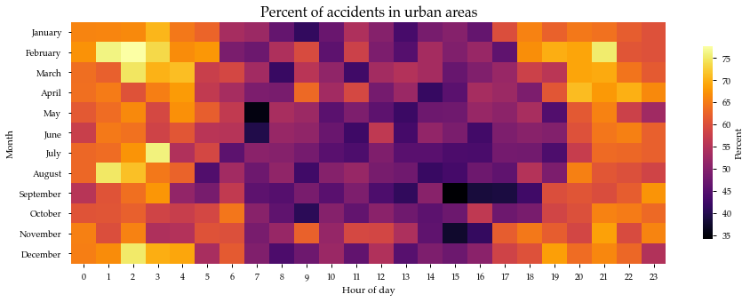

```python
plot_dat = accidents[['Month','Hour','Urban']].pivot(index='Month', columns = 'Hour')

fig, ax = plt.subplots(figsize = (15, 5))
sns.heatmap(plot_dat, cmap='inferno', ax=ax,
    cbar_kws={'shrink':0.8, 'label': 'Percent'})
ax.set_xlabel('Hour of day');
ax.set_xticklabels(list(range(24)), rotation=0);
ax.set_title('Percent of accidents in urban areas', size=16);
```